# Practical Machine Learning Project

Simran

06/01/2021

Using devices such as Jawbone Up, Nike FuelBand, and Fitbit it is now possible to collect a large amount of data about personal activity relatively inexpensively. These type of devices are part of the quantified self movement – a group of enthusiasts who take measurements about themselves regularly to improve their health, to find patterns in their behavior, or because they are tech geeks. One thing that people regularly do is quantify how much of a particular activity they do, but they rarely quantify how well they do it. In this project, your goal will be to use data from accelerometers on the belt, forearm, arm, and dumbell of 6 participants. They were asked to perform barbell lifts correctly and incorrectly in 5 different ways. The goal of this project is to predict the manner of performing unilateral dumbbell biceps curls based on data from accelerometers on the belt, forearm, arm, and dumbell of 6 participants. The 5 possible methods include -

A: exactly according to the specification B: throwing the elbows to the front C: lifting the dumbbell only halfway D: lowering the dumbbell only halfway E: throwing the hips to the front

```r
library(knitr)
library(caret)
```

```r
library(rpart)
library(rpart.plot)
library(rattle)
library(randomForest)
library(corrplot)
set.seed(12345)
```

Setting working directory

```r
getwd()
```

```
## [1] "C:/Users/dell/Documents"
```

Loading data

```r
train_data <- read.csv("C:/Users/dell/Documents/pml-training.csv", header = TRUE)
dim(train_data)
```

```
## [1] 19622   160
```

```r
test_data<-read.csv("C:/Users/dell/Documents/pml-testing.csv", header = TRUE)
dim(test_data)
```

```
## [1]  20 160
```

Removing missing values.Hence the dimension of the data set is reduced

```r
trainData<- train_data[, colSums(is.na(train_data)) == 0]
dim(trainData)
```

```
## [1] 19622    93
```

```r
validData <- test_data[, colSums(is.na(test_data)) == 0]
dim(validData)
```

```
## [1] 20 60
```

```r
trainData <- trainData[, -c(1:7)]
dim(trainData)
```

```
## [1] 19622    86
```

```r
validData <- validData[, -c(1:7)]
dim(validData)
```

```
## [1] 20 53
```

```r
set.seed(1234)
inTrain <- createDataPartition(train_data$classe, p = 0.75, list = FALSE)
trainData <-trainData[inTrain, ]
testData <- trainData[-inTrain, ]
dim(trainData)
```

```
## [1] 14718    86
```

```r
dim(testData)
```

```
## [1] 3682   86
```

Removing the variables with zero variance

```r
NZV <- nearZeroVar(trainData)
trainData <-trainData[, -NZV]
testData  <-testData[, -NZV]
dim(trainData)
```

```
## [1] 14718    53
```

```r
dim(testData)
```

```
## [1] 3682   53
```

Before building the model we analyse the correlation among variables

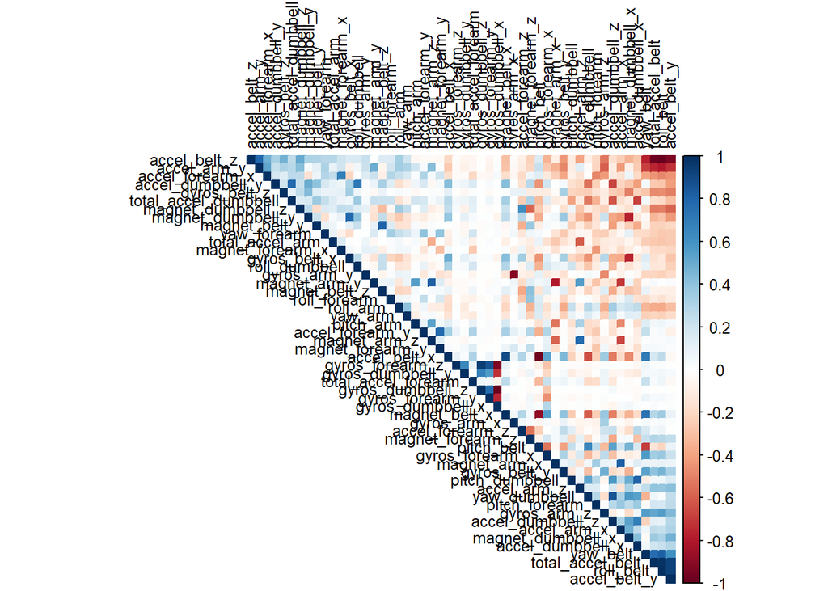

```r
correlation_mat <- cor(trainData[, -53])
corrplot(correlation_mat, order = "FPC", method = "color", type = "upper",
         tl.cex = 0.8, tl.col = rgb(0, 0, 0))
```

1. Method: Random Forest

Determining the model

```r
modFit <- randomForest(classe ~. , data=trainData)
```

```r
predictions <- predict(modFit, testData, type = "class")
rf<-confusionMatrix(predictions, testData$classe)
rf
```

```
## Confusion Matrix and Statistics
##
##           Reference
## Prediction    A    B    C    D    E
##          A 1040    0    0    0    0
##          B    0  699    0    0    0
##          C    0    0  665    0    0
##          D    0    0    0  603    0
##          E    0    0    0    0  675
##
## Overall Statistics
##
##                Accuracy : 1
##                  95% CI : (0.999, 1)
##     No Information Rate : 0.2825
##     P-Value [Acc > NIR] : < 2.2e-16
##
##                   Kappa : 1
##
##  Mcnemar's Test P-Value : NA
##
## Statistics by Class:
##
##                      Class: A Class: B Class: C Class: D Class: E
## Sensitivity            1.0000   1.0000   1.0000   1.0000   1.0000
## Specificity            1.0000   1.0000   1.0000   1.0000   1.0000
## Pos Pred Value         1.0000   1.0000   1.0000   1.0000   1.0000
## Neg Pred Value         1.0000   1.0000   1.0000   1.0000   1.0000
## Prevalence             0.2825   0.1898   0.1806   0.1638   0.1833
## Detection Rate         0.2825   0.1898   0.1806   0.1638   0.1833
## Detection Prevalence   0.2825   0.1898   0.1806   0.1638   0.1833
## Balanced Accuracy      1.0000   1.0000   1.0000   1.0000   1.0000
```

Plotting the accuracy

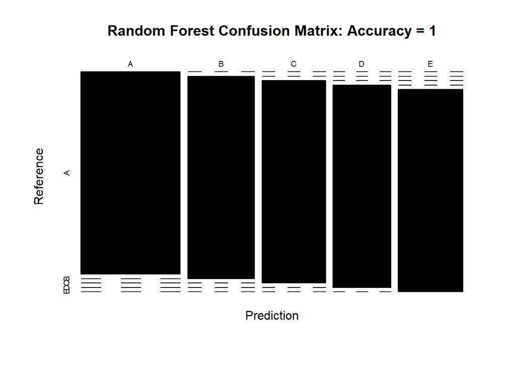

```r
plot(rf$table, col = rf$byClass, main = paste("Random Forest Confusion Matrix: Accuracy =", round(rf$overall['Accuracy'], 4)))
```

2)Decision Tree

Determining the model

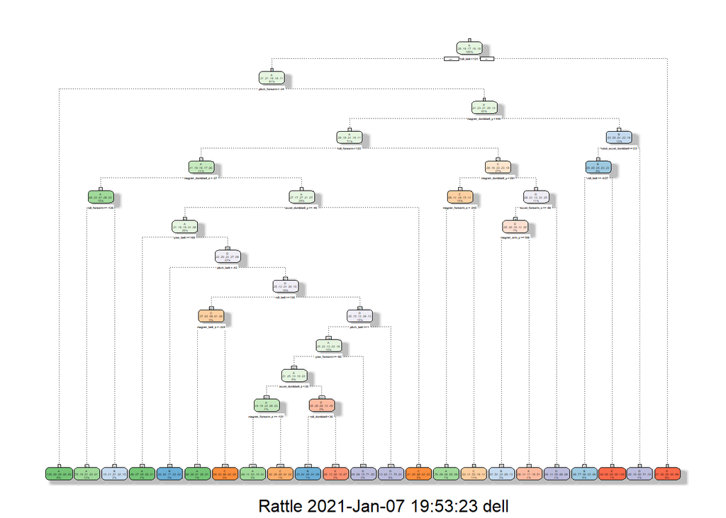

```r
set.seed(12345)
decisionTree <- rpart(classe ~ ., data=trainData, method="class")
fancyRpartPlot(decisionTree)
```

Validating the model on test data and finding the accuracy

```r
predictTree <- predict(decisionTree, testData, type = "class")
dtree <- confusionMatrix(predictTree, testData$classe)
dtree
```

```
## Confusion Matrix and Statistics
##
##           Reference
## Prediction   A   B   C   D   E
##          A 895 111  12  20  18
##          B  36 415  55  46  37
##          C  46 101 532  98  80
##          D  42  47  44 402  40
##          E  21  25  22  37 500
##
## Overall Statistics
##
##                Accuracy : 0.7452
##                  95% CI : (0.7308, 0.7593)
##     No Information Rate : 0.2825
##     P-Value [Acc > NIR] : < 2.2e-16
##
##                   Kappa : 0.6779
##
##  Mcnemar's Test P-Value : < 2.2e-16
##
## Statistics by Class:
##
##                      Class: A Class: B Class: C Class: D Class: E
## Sensitivity            0.8606   0.5937   0.8000   0.6667   0.7407
## Specificity            0.9391   0.9417   0.8923   0.9438   0.9651
## Pos Pred Value         0.8475   0.7046   0.6208   0.6991   0.8264
## Neg Pred Value         0.9448   0.9082   0.9529   0.9353   0.9431
## Prevalence             0.2825   0.1898   0.1806   0.1638   0.1833
## Detection Rate         0.2431   0.1127   0.1445   0.1092   0.1358
## Detection Prevalence   0.2868   0.1600   0.2328   0.1562   0.1643
## Balanced Accuracy      0.8998   0.7677   0.8461   0.8052   0.8529
```

Plotting the accuracy

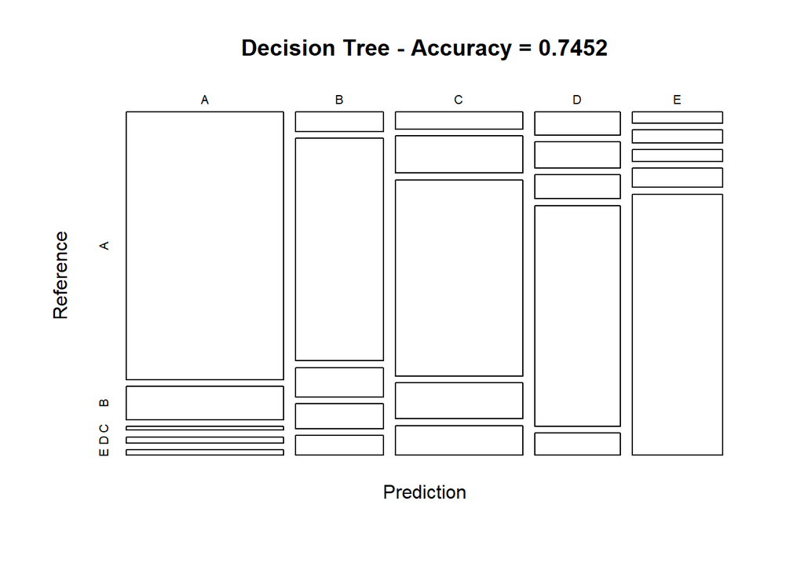

```r
# plot matrix results
plot(dtree$table, col = dtree$byClass,
     main = paste("Decision Tree - Accuracy =", round(dtree$overall['Accuracy'], 4)))
```

```r
FinalTestPred <- predict(modFit,newdata=trainData)
FinalTestPred
```

[output not shown]

[output cut: 2212 more lines]

[output not shown]